# EDA on Human Chr8:107148531-145078634 VCF

#### load

```python
import pandas as pd
import numpy as np
import scipy as sp
import matplotlib.pyplot as plt
import seaborn as sns
from tqdm import tqdm
import warnings
warnings.filterwarnings('ignore')
from IPython.core.interactiveshell import InteractiveShell
InteractiveShell.ast_node_interactivity = "all"
```

```python
df = pd.read_csv('chr8-unfiltered.tsv', sep="\t")
df['MQ'] = pd.to_numeric(df['MQ'], errors='coerce')
```

```python
df.tail()
```

|  | CHROM | POS | ID | REF | ALT | QUAL | FILTER | AC | AF | AN | ... | MQ | MQRankSum | NEGATIVE_TRAIN_SITE | POSITIVE_TRAIN_SITE | QD | RAW_MQandDP | ReadPosRankSum | SOR | VQSLOD | culprit |
| --- | --- | --- | --- | --- | --- | --- | --- | --- | --- | --- | --- | --- | --- | --- | --- | --- | --- | --- | --- | --- | --- |
| 4737298 | chr8 | 145078548 | . | T | G | 65.29 | VQSRTrancheSNP99.80to99.90 | 2 | 0.000086 | 23234 | ... | 47.48 | NaN | NaN | NaN | 21.76 | NaN | NaN | 2.833 | -40.840 | SOR |
| 4737299 | chr8 | 145078572 | . | C | T | 559.45 | VQSRTrancheSNP99.80to99.90 | 5 | 0.000217 | 23040 | ... | 54.26 | 0.674 | NaN | NaN | 22.38 | NaN | 1.38 | 3.014 | -47.140 | SOR |
| 4737300 | chr8 | 145078588 | . | C | G | 203.21 | VQSRTrancheSNP99.80to99.90 | 4 | 0.000176 | 22766 | ... | 58.47 | NaN | NaN | NaN | 25.40 | NaN | NaN | 4.407 | -89.530 | SOR |
| 4737301 | chr8 | 145078608 | . | T | A | 37.99 | VQSRTrancheSNP99.80to99.90 | 2 | 0.000092 | 21758 | ... | 43.67 | NaN | NaN | NaN | 18.99 | NaN | NaN | 2.303 | -32.220 | SOR |
| 4737302 | chr8 | 145078634 | . | A | ATATT | 25713.10 | PASS | 2 | 0.250000 | 8 | ... | 45.28 | NaN | True | NaN | 31.31 | NaN | NaN | 2.303 | -4.786 | DP |

5 rows × 30 columns

#### collinearity

```python
corr_matrix = df.corr().abs()
[column for column in corr_matrix.columns if any((corr_matrix[column] > 0.90) & (corr_matrix[column] < 1.00))]
```

```
['QUAL', 'AC', 'AF']
```

```python
df = df.drop(['CHROM', 'AN', 'DB', 'DS', 'END', 'MLEAC', 'MLEAF','NEGATIVE_TRAIN_SITE', 'POSITIVE_TRAIN_SITE','RAW_MQandDP'], axis=1)
```

```python
corr_matrix.dropna(thresh=2).dropna(axis=1, thresh=2)
```

|  | POS | QUAL | AC | AF | BaseQRankSum | DP | ExcessHet | FS | InbreedingCoeff | MQRankSum | QD | ReadPosRankSum | SOR | VQSLOD |
| --- | --- | --- | --- | --- | --- | --- | --- | --- | --- | --- | --- | --- | --- | --- |
| POS | 1.000000 | 0.011158 | 0.009925 | 0.009991 | 0.015285 | 0.114860 | 0.018215 | 0.008679 | 0.006098 | 0.001547 | 0.000230 | 0.001973 | 0.003597 | 0.003696 |
| QUAL | 0.011158 | 1.000000 | 0.989589 | 0.988961 | 0.015429 | 0.118142 | 0.027310 | 0.046487 | 0.164333 | 0.015441 | 0.299246 | 0.009918 | 0.028058 | 0.010642 |
| AC | 0.009925 | 0.989589 | 1.000000 | 0.999615 | 0.014637 | 0.106276 | 0.025061 | 0.044139 | 0.171972 | 0.021122 | 0.297514 | 0.010821 | 0.025237 | 0.004942 |
| AF | 0.009991 | 0.988961 | 0.999615 | 1.000000 | 0.014653 | 0.104831 | 0.024967 | 0.043864 | 0.173019 | 0.021188 | 0.297699 | 0.010834 | 0.024826 | 0.002258 |
| BaseQRankSum | 0.015285 | 0.015429 | 0.014637 | 0.014653 | 1.000000 | 0.030379 | 0.132760 | 0.144087 | 0.007864 | 0.018134 | 0.121136 | 0.076682 | 0.169079 | 0.061284 |
| DP | 0.114860 | 0.118142 | 0.106276 | 0.104831 | 0.030379 | 1.000000 | 0.136161 | 0.085735 | 0.083558 | 0.024657 | 0.079550 | 0.002996 | 0.096345 | 0.044453 |
| ExcessHet | 0.018215 | 0.027310 | 0.025061 | 0.024967 | 0.132760 | 0.136161 | 1.000000 | 0.236852 | 0.353894 | 0.009281 | 0.159474 | 0.018360 | 0.351015 | 0.131918 |
| FS | 0.008679 | 0.046487 | 0.044139 | 0.043864 | 0.144087 | 0.085735 | 0.236852 | 1.000000 | 0.118491 | 0.041841 | 0.238894 | 0.004657 | 0.689142 | 0.391822 |
| InbreedingCoeff | 0.006098 | 0.164333 | 0.171972 | 0.173019 | 0.007864 | 0.083558 | 0.353894 | 0.118491 | 1.000000 | 0.008024 | 0.217039 | 0.015421 | 0.121767 | 0.068077 |
| MQRankSum | 0.001547 | 0.015441 | 0.021122 | 0.021188 | 0.018134 | 0.024657 | 0.009281 | 0.041841 | 0.008024 | 1.000000 | 0.114491 | 0.029258 | 0.058391 | 0.029976 |
| QD | 0.000230 | 0.299246 | 0.297514 | 0.297699 | 0.121136 | 0.079550 | 0.159474 | 0.238894 | 0.217039 | 0.114491 | 1.000000 | 0.026160 | 0.329387 | 0.101751 |
| ReadPosRankSum | 0.001973 | 0.009918 | 0.010821 | 0.010834 | 0.076682 | 0.002996 | 0.018360 | 0.004657 | 0.015421 | 0.029258 | 0.026160 | 1.000000 | 0.005284 | 0.003294 |
| SOR | 0.003597 | 0.028058 | 0.025237 | 0.024826 | 0.169079 | 0.096345 | 0.351015 | 0.689142 | 0.121767 | 0.058391 | 0.329387 | 0.005284 | 1.000000 | 0.320589 |
| VQSLOD | 0.003696 | 0.010642 | 0.004942 | 0.002258 | 0.061284 | 0.044453 | 0.131918 | 0.391822 | 0.068077 | 0.029976 | 0.101751 | 0.003294 | 0.320589 | 1.000000 |

```python
corr_matrix.unstack().sort_values(ascending=False).head(40)
```

```
POS              POS                1.000000
QUAL             QUAL               1.000000
SOR              SOR                1.000000
ReadPosRankSum   ReadPosRankSum     1.000000
QD               QD                 1.000000
MQRankSum        MQRankSum          1.000000
InbreedingCoeff  InbreedingCoeff    1.000000
FS               FS                 1.000000
ExcessHet        ExcessHet          1.000000
DP               DP                 1.000000
BaseQRankSum     BaseQRankSum       1.000000
AF               AF                 1.000000
AC               AC                 1.000000
VQSLOD           VQSLOD             1.000000
AF               AC                 0.999615
AC               AF                 0.999615
                 QUAL               0.989589
QUAL             AC                 0.989589
AF               QUAL               0.988961
QUAL             AF                 0.988961
SOR              FS                 0.689142
FS               SOR                0.689142
VQSLOD           FS                 0.391822
FS               VQSLOD             0.391822
InbreedingCoeff  ExcessHet          0.353894
ExcessHet        InbreedingCoeff    0.353894
                 SOR                0.351015
SOR              ExcessHet          0.351015
                 QD                 0.329387
QD               SOR                0.329387
SOR              VQSLOD             0.320589
VQSLOD           SOR                0.320589
QUAL             QD                 0.299246
QD               QUAL               0.299246
AF               QD                 0.297699
QD               AF                 0.297699
AC               QD                 0.297514
QD               AC                 0.297514
FS               QD                 0.238894
QD               FS                 0.238894
dtype: float64
```

## I'm interested in doing regression/classifiers, so I need to deal with NaN's

```python
df.isnull().sum()
```

```
POS                   0
ID                    0
REF                   0
ALT                   0
QUAL                  0
FILTER                0
AC                    0
AF                    1
BaseQRankSum       5365
DP                    0
ExcessHet             0
FS                    0
InbreedingCoeff       5
MQRankSum          5365
QD                 8708
ReadPosRankSum     9829
SOR                   0
VQSLOD                0
culprit               0
dtype: int64
```

```python
df[df['AF'].isna()]
```

|  | POS | ID | REF | ALT | QUAL | FILTER | AC | AF | BaseQRankSum | DP | ExcessHet | FS | InbreedingCoeff | MQRankSum | QD | ReadPosRankSum | SOR | VQSLOD | culprit |
| --- | --- | --- | --- | --- | --- | --- | --- | --- | --- | --- | --- | --- | --- | --- | --- | --- | --- | --- | --- |
| 3205146 | 133313568 | rs76475253 | A | T | 36876.4 | PASS | 0 | NaN | NaN | 507549 | 3.0103 | 0.0 | NaN | NaN | 30.67 | NaN | 0.693 | -6.275 | DP |

#### AC and AF = 0, means this variant was seen a total of 0 times, remove row #### Mapping quality = error in read alignment, Base quality = error in base calling #### MQ = root-mean-square of mapping quality of reads across samples. #### MQRankSum = difference in mapping quality between REF and ALT alleles (closer to 0 is better) #### Impute 0s for MQRankSum #### BaseQRankSum = different in base quality of REF vs ALT. Impute 0s #### ReadPosRankSum = relative positioning of REF versus ALT alleles within reads. Impute 0s #### Both InbreedingCoeff and ExcessHet measure consanguinuity #### SOR and FS measure strand bias. Impute FS with 0

#### drop collinear, constant, NaN features. drop features where a normalized alternative is present (eg. AF = AC/AN)

```python
df = df.drop([3205146]).reset_index(drop=True)
```

```python
df = df.fillna(0)
```

### Distribution of variants

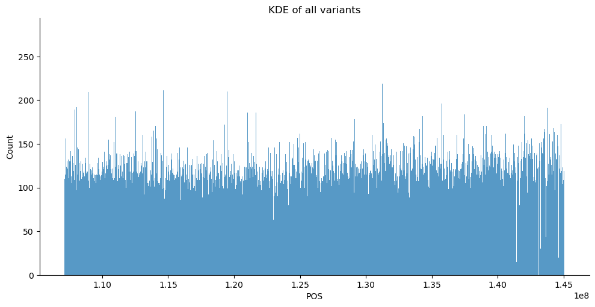

```python
#number of variants per 1000bp
sns.displot(data=df, x='POS', binwidth=1000, height=5, aspect=2).set(title="KDE of all variants");
```

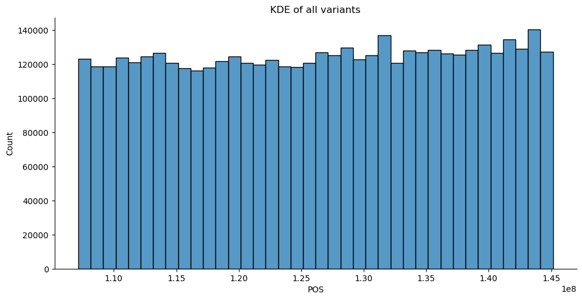

```python
#number of variants per 1 Mbp
sns.displot(data=df, x='POS', binwidth=1000000, height=5, aspect=2).set(title="KDE of all variants");
```

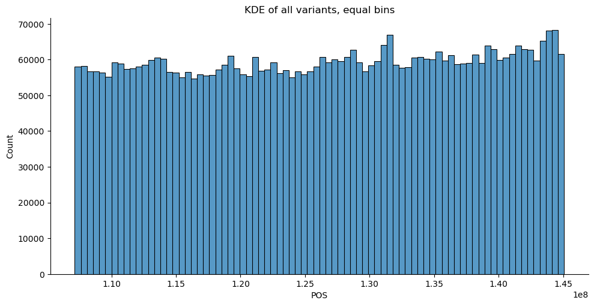

```python
sns.displot(data=df, x='POS', bins=80, height=5, aspect=2).set(title="KDE of all variants, equal bins");
```

#### Qn: Binning by width (eg. # of bp) or by # of variants (into X equally-sized bins)? Equally-sized bins avoids having a much smaller final bin for 140Mbp+

#### Qn: When analyzing a chromosome, what's the "right" granularity?

```python
#for each variant locus, pos_dist = "distance to the next variant"
pos_dist=[]
for i in range(0,df['POS'].index[-1]):
    pos_dist.append(df['POS'][i+1] - df['POS'][i])
```

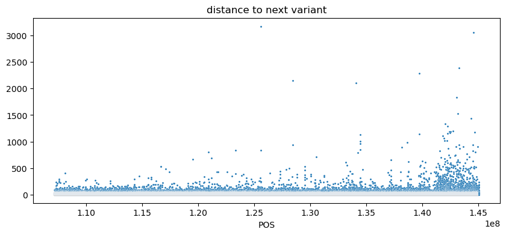

```python
plt.figure(figsize=(10, 4))
sns.scatterplot(y=pos_dist+[0], x=df['POS'], s=5).set(title="distance to next variant");
```

### Distribution of filtered variants

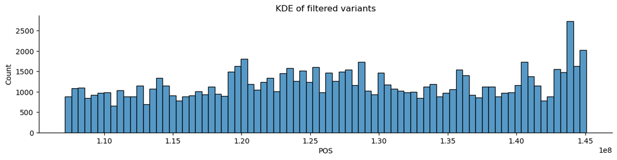

```python
#~0.5 Mbp bins
sns.displot(data=df.loc[df['FILTER'] != 'PASS'], x='POS', bins=80, height=3, aspect=4).set(title="KDE of filtered variants");
```

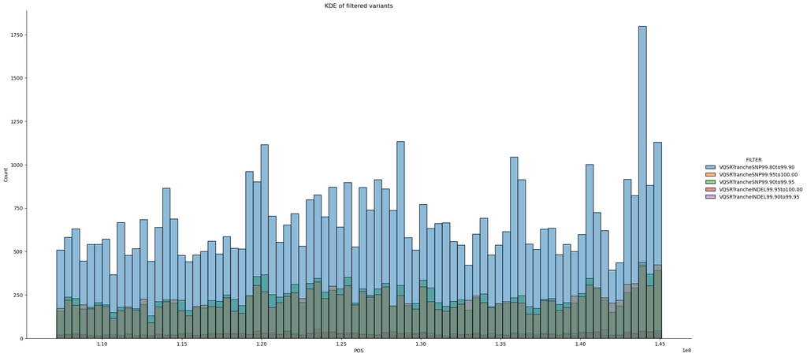

```python
#0.5 Mbp bins
sns.displot(data=df.loc[df['FILTER'] != 'PASS'], x='POS', bins=80, height=10, aspect=2, hue='FILTER').set(title="KDE of filtered variants");
```

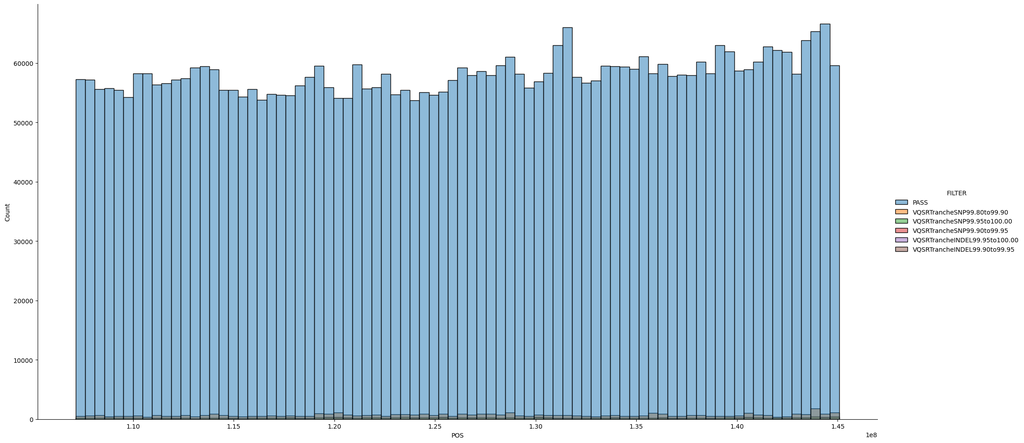

```python
sns.displot(data=df, x='POS', bins=80, height=10, aspect=2, hue='FILTER');
```

#### Is it more likely for variants closer to the end of the chromosome to get filtered?

```python
bin_labels=pd.cut(df['POS'], bins=80, retbins=True, precision=2)[1] // 10000 / 100
df['bin']=pd.cut(df['POS'], bins=80, labels=bin_labels[0:-1])
```

```python
def filtered(s):
    if s == 'PASS':
        return 0
    else:
        return 1

df['Filtered'] = df['FILTER'].apply (lambda row: filtered(row))
```

```python
df_bin = df.groupby(by='bin').mean().reset_index()
```

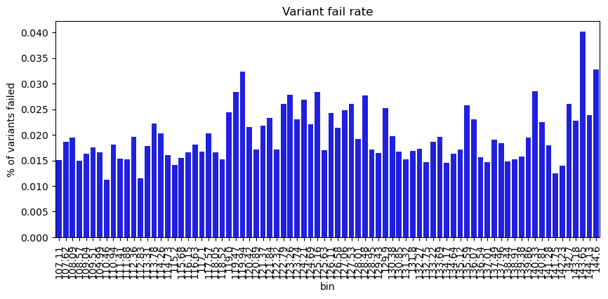

```python
plt.figure(figsize=(10, 4))
sns.barplot(data=df_bin, x='bin', y='Filtered', color='blue').set(title='Variant fail rate', ylabel='% of variants failed');
plt.xticks(rotation=90);
```

### Indels

```python
def mutation_type(ref, alt):
    if len(ref) == len(alt):
        return "SNV"
    if len(ref) > len(alt):
        return "DEL"
    if len(ref) < len(alt):
        return "INS"
```

```python
df['TYPE'] = df.apply(lambda x: mutation_type(x['REF'], x['ALT']), axis=1)
```

```python
df['TYPE'].value_counts()
df['TYPE'].value_counts() / len(df)
```

[output not shown]

```
SNV    0.931080
DEL    0.048373
INS    0.020547
Name: TYPE, dtype: float64
```

```python
pd.crosstab(df['FILTER'], df['TYPE'])
```

| TYPE FILTER | DEL | INS | SNV |
| --- | --- | --- | --- |
| PASS | 226658 | 95913 | 4320593 |
| VQSRTrancheINDEL99.90to99.95 | 1241 | 739 | 0 |
| VQSRTrancheINDEL99.95to100.00 | 1260 | 685 | 0 |
| VQSRTrancheSNP99.80to99.90 | 0 | 0 | 53778 |
| VQSRTrancheSNP99.90to99.95 | 0 | 0 | 18910 |
| VQSRTrancheSNP99.95to100.00 | 0 | 0 | 17525 |

```python
pd.crosstab(df['Filtered'], df['TYPE'])
```

| TYPE Filtered | DEL | INS | SNV |
| --- | --- | --- | --- |
| 0 | 226658 | 95913 | 4320593 |
| 1 | 2501 | 1424 | 90213 |

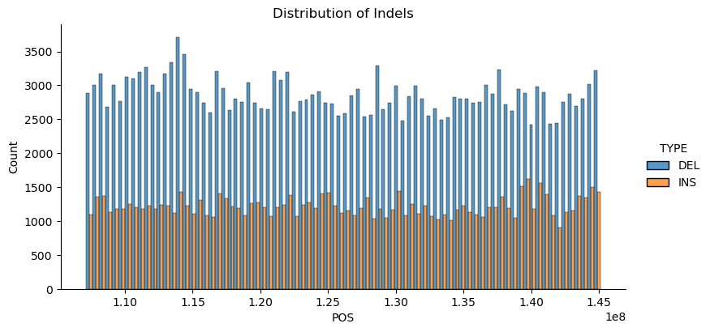

```python
sns.displot(data=df.loc[df['TYPE'] != 'SNV'], x='POS', bins=80, height=4, aspect=2, hue='TYPE', multiple='dodge').set(title='Distribution of Indels');
```

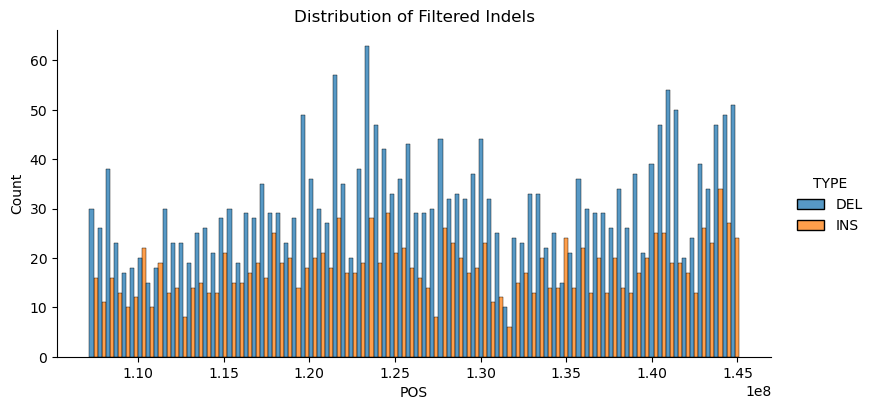

```python
sns.displot(data=df.loc[(df['TYPE'] != 'SNV') & (df['FILTER'] != 'PASS')], x='POS', bins=80, height=4, aspect=2, hue='TYPE', multiple='dodge').set(title='Distribution of Filtered Indels');
```

```python
df['SNV?'] = (df['TYPE'] == 'SNV') * 1
```

```python
df_bin = df.groupby(by='bin').mean().reset_index()
df_bin
```

|  | bin | POS | QUAL | AC | AF | BaseQRankSum | DP | ExcessHet | FS | InbreedingCoeff | MQRankSum | QD | ReadPosRankSum | SOR | VQSLOD | Filtered | SNV? |
| --- | --- | --- | --- | --- | --- | --- | --- | --- | --- | --- | --- | --- | --- | --- | --- | --- | --- |
| 0 | 107.11 | 1.073946e+08 | 297409.947306 | 473.378801 | 0.006511 | -0.072289 | 1.251872e+06 | 4.122741 | 3.747447 | 0.006832 | 0.004122 | 13.176388 | 0.107673 | 0.895332 | 7.644946 | 0.015093 | 0.931506 |
| 1 | 107.62 | 1.078594e+08 | 278175.000986 | 457.546295 | 0.006293 | -0.089049 | 1.249935e+06 | 4.564125 | 3.929008 | 0.007090 | -0.027020 | 13.104905 | 0.095284 | 0.911824 | 5.887952 | 0.018583 | 0.925135 |
| 2 | 108.09 | 1.083314e+08 | 351682.343112 | 573.625663 | 0.007889 | -0.130170 | 1.250366e+06 | 4.461917 | 4.000841 | 0.007102 | -0.016992 | 13.145126 | 0.093645 | 0.915031 | 6.072337 | 0.019464 | 0.920009 |
| 3 | 108.57 | 1.088063e+08 | 205200.510597 | 342.084668 | 0.004707 | -0.064801 | 1.248242e+06 | 4.634684 | 3.799855 | 0.006143 | 0.002363 | 13.092807 | 0.103140 | 0.897023 | 7.384689 | 0.014906 | 0.932534 |
| 4 | 109.04 | 1.092832e+08 | 307538.440352 | 496.341136 | 0.006827 | -0.094496 | 1.250592e+06 | 4.571244 | 3.810860 | 0.006849 | -0.002309 | 13.175458 | 0.105949 | 0.893489 | 7.167652 | 0.016244 | 0.925821 |
| ... | ... | ... | ... | ... | ... | ... | ... | ... | ... | ... | ... | ... | ... | ... | ... | ... | ... |
| 75 | 142.70 | 1.429444e+08 | 419350.592841 | 648.998493 | 0.008933 | -0.043567 | 1.280613e+06 | 5.724893 | 4.284629 | 0.007769 | -0.030143 | 13.067358 | 0.098571 | 0.929236 | 4.627119 | 0.026048 | 0.932571 |
| 76 | 143.18 | 1.434230e+08 | 373503.186621 | 561.434207 | 0.007739 | 0.014389 | 1.308092e+06 | 6.154439 | 4.354943 | 0.008277 | 0.002137 | 13.176970 | 0.110861 | 0.916724 | 4.775213 | 0.022717 | 0.937666 |
| 77 | 143.65 | 1.438911e+08 | 226408.836563 | 347.830363 | 0.004816 | 0.053743 | 1.285911e+06 | 6.535905 | 4.636267 | 0.006308 | -0.003873 | 12.871946 | 0.118594 | 0.940656 | 2.985185 | 0.040195 | 0.938944 |
| 78 | 144.13 | 1.443691e+08 | 236635.523121 | 353.652811 | 0.004866 | 0.038927 | 1.303029e+06 | 6.196560 | 4.386475 | 0.006535 | -0.003322 | 12.964316 | 0.111522 | 0.919768 | 5.233890 | 0.023877 | 0.933895 |
| 79 | 144.60 | 1.448445e+08 | 199603.981066 | 331.858362 | 0.004613 | -0.063800 | 1.251672e+06 | 6.526952 | 4.505552 | 0.006825 | -0.042825 | 12.904501 | 0.094710 | 0.971069 | -3.463836 | 0.032781 | 0.924491 |

80 rows × 17 columns

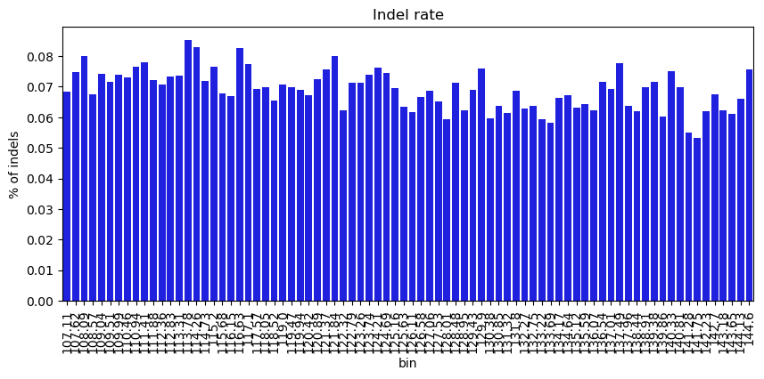

```python
# % of variants that are insertions or deletions
plt.figure(figsize=(10, 4))
sns.barplot(data=df_bin, x='bin', y=1-df_bin['SNV?'], color='blue').set(title='Indel rate', ylabel='% of indels');
plt.xticks(rotation=90);
```

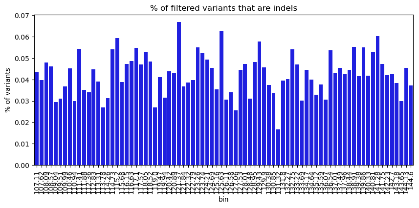

```python
# % of filtered variants that are indels
filtered_bin=df.loc[df['FILTER'] != 'PASS'].groupby(by=['bin']).mean().reset_index()
plt.figure(figsize=(10, 4))
sns.barplot(data=filtered_bin, x='bin', y=1-filtered_bin['SNV?'], color='blue').set(title='% of filtered variants that are indels', ylabel='% of variants');
plt.xticks(rotation=90);
```

### Read depth

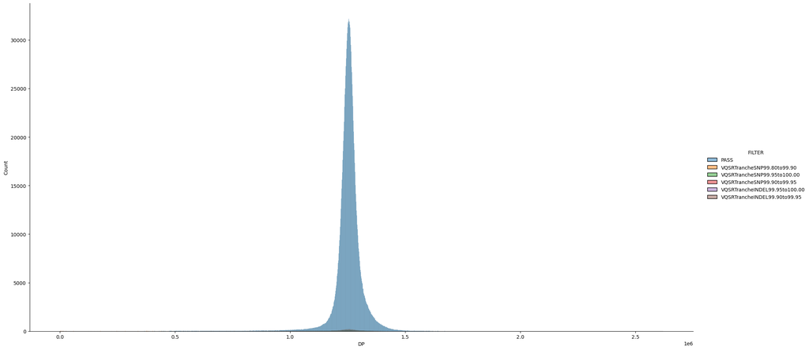

```python
sns.displot(data=df.loc[df['DP'] < 5000000], x='DP', height=10, aspect=2, hue='FILTER');
```

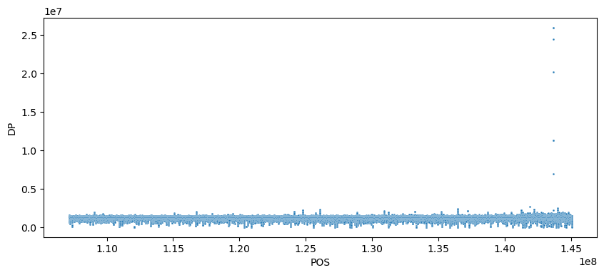

```python
plt.figure(figsize=(10, 4))
sns.scatterplot(data=df, x='POS', y='DP', s=4, );
```

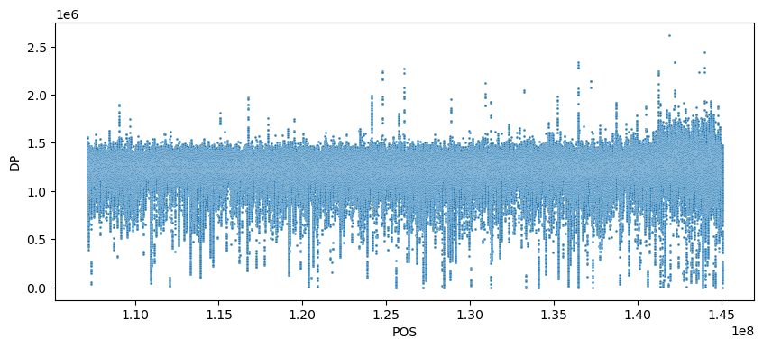

```python
plt.figure(figsize=(10, 4))
sns.scatterplot(data=df.loc[df['DP'] < 5000000], x='POS', y='DP', s=4, );
```

```python
df.loc[df['DP'] > 5000000]
```

|  | POS | ID | REF | ALT | QUAL | FILTER | AC | AF | BaseQRankSum | DP | ... | MQRankSum | QD | ReadPosRankSum | SOR | VQSLOD | culprit | bin | Filtered | TYPE | SNV? |
| --- | --- | --- | --- | --- | --- | --- | --- | --- | --- | --- | --- | --- | --- | --- | --- | --- | --- | --- | --- | --- | --- |
| 4540915 | 143669565 | . | G | A | 278.32 | VQSRTrancheSNP99.95to100.00 | 1 | 0.000014 | 2.700 | 25982071 | ... | 1.250 | 3.81 | 2.760 | 0.555 | -6062.00 | DP | 143.65 | 1 | SNV | 1 |
| 4540916 | 143669569 | . | C | G | 54.33 | VQSRTrancheSNP99.95to100.00 | 1 | 0.000014 | 0.031 | 25979162 | ... | -0.656 | 1.94 | -1.012 | 0.515 | -6060.00 | DP | 143.65 | 1 | SNV | 1 |
| 4540917 | 143669575 | rs79948061 | T | C | 18624.00 | VQSRTrancheSNP99.95to100.00 | 13 | 0.000186 | -0.156 | 20243246 | ... | -1.752 | 6.10 | 0.672 | 0.619 | -3565.00 | DP | 143.65 | 1 | SNV | 1 |
| 4540918 | 143669586 | . | G | GGTTGGGCTGC | 173.36 | VQSRTrancheINDEL99.95to100.00 | 1 | 0.000014 | 1.950 | 24457743 | ... | -1.293 | 0.92 | -2.943 | 1.161 | -1006.00 | DP | 143.65 | 1 | INS | 0 |
| 4540919 | 143669595 | rs4874438 | G | A | 204.39 | VQSRTrancheSNP99.95to100.00 | 2 | 0.000028 | 0.928 | 11290387 | ... | -1.741 | 2.55 | -0.813 | 1.269 | -996.80 | DP | 143.65 | 1 | SNV | 1 |
| 4540920 | 143669603 | . | G | A | 7756.76 | VQSRTrancheSNP99.95to100.00 | 54 | 0.000743 | 0.566 | 11280314 | ... | -1.509 | 4.23 | -1.317 | 3.962 | -1080.00 | DP | 143.65 | 1 | SNV | 1 |
| 4540921 | 143669617 | . | T | TTTTACAGGTTGGGCTGCAGATTGGGAACAGATGTGGGTTTTACAG... | 784.35 | VQSRTrancheINDEL99.95to100.00 | 1 | 0.000014 | 0.035 | 6917239 | ... | -3.917 | 17.83 | -4.284 | 1.447 | -70.56 | DP | 143.65 | 1 | INS | 0 |

7 rows × 23 columns

#### ~50bp with extremely high read depth.

### Heterozygosity and strand bias (phred-scaled, lower is better)

```python
sp.stats.normaltest(df['ExcessHet'])
sp.stats.normaltest(df['FS'])
```

```
NormaltestResult(statistic=6788475.751460797, pvalue=0.0)
```

```
NormaltestResult(statistic=9148788.236572504, pvalue=0.0)
```

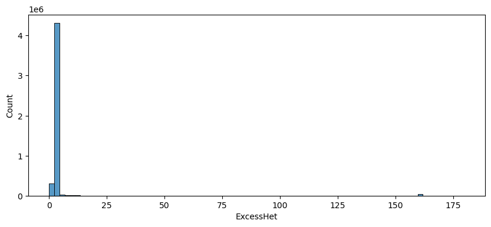

```python
plt.figure(figsize=(10, 4))
sns.histplot(data=df['ExcessHet'], bins=80);
```

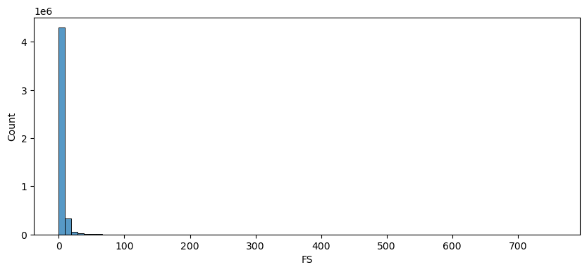

```python
plt.figure(figsize=(10, 4))
sns.histplot(data=df['FS'], bins=80);
```

#### Both highly skewed due to Phred scaling. Recalculate to %(ie p-value)

```python
df['P_Het'] = 10 ** (-1 * df['ExcessHet'] / 10 )
df['P_FS'] = 10 ** (-1 * df['FS'] / 10 )
```

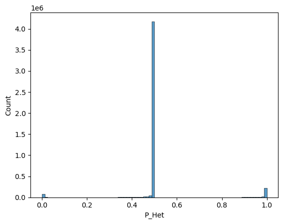

```python
sns.histplot(data=df['P_Het'], bins=80);
```

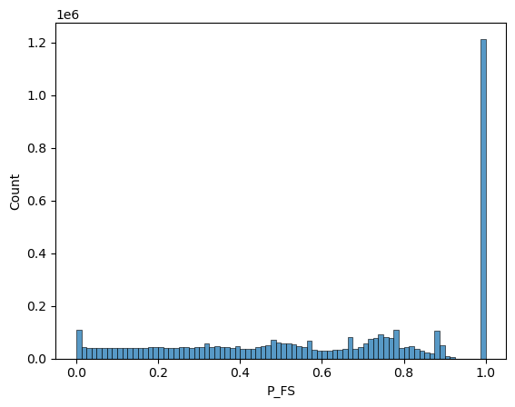

```python
sns.histplot(data=df['P_FS'], bins=80);
```

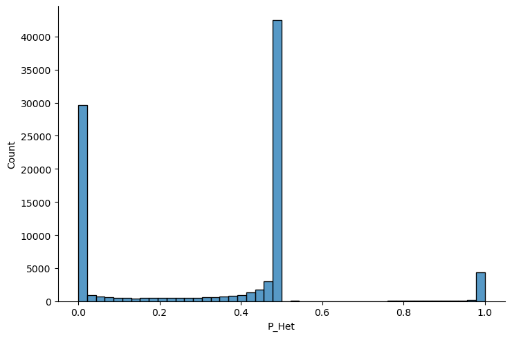

```python
sns.displot(data=df.loc[df['Filtered']==1], x='P_Het', height=5, aspect=1.5)
```

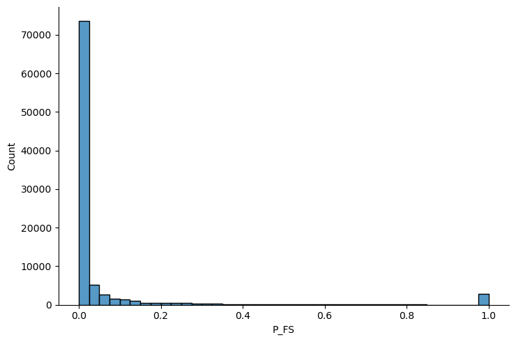

```python
sns.displot(data=df.loc[df['Filtered']==1], x='P_FS', bins=40, height=5, aspect=1.5);
```

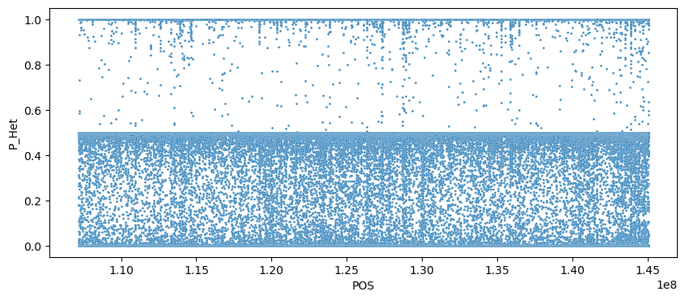

```python
plt.figure(figsize=(10, 4))
sns.scatterplot(data=df.loc[df['Filtered']==1], x='POS', y='P_Het', s=4);
```

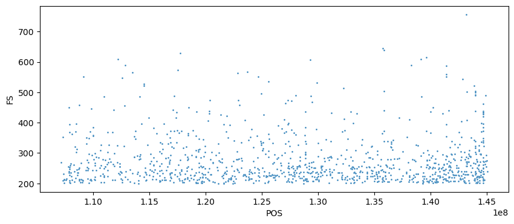

```python
plt.figure(figsize=(10, 4))
sns.scatterplot(data=df.loc[(df['Filtered']==1) & (df['FS'] > 200)], x='POS', y='FS', s=4);
```

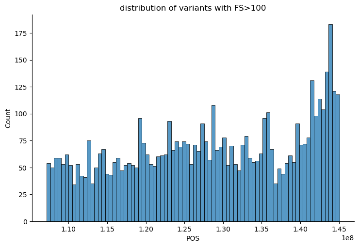

```python
sns.displot(data=df.loc[(df['FS'] > 100)], x='POS', height=5, aspect=1.5, bins=80).set(title='distribution of variants with FS>100');
```

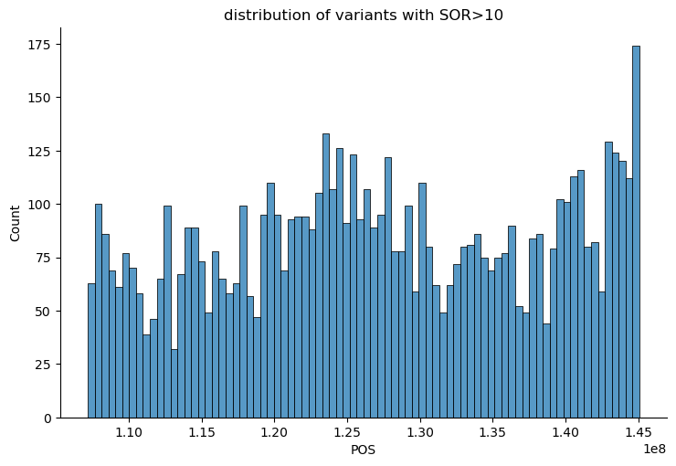

```python
sns.displot(data=df.loc[(df['SOR'] > 10)], x='POS', height=5, aspect=1.5, bins=80).set(title='distribution of variants with SOR>10');
```

#### So there does seem to be regions where strandbias is more likely, especially near the telomere

### Skimming through other metrics

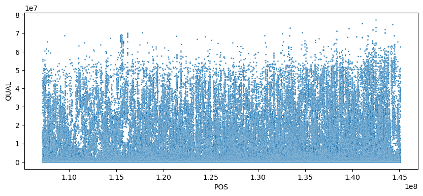

```python
plt.figure(figsize=(10, 4))
sns.scatterplot(data=df, x='POS', y='QUAL', s=4);
```

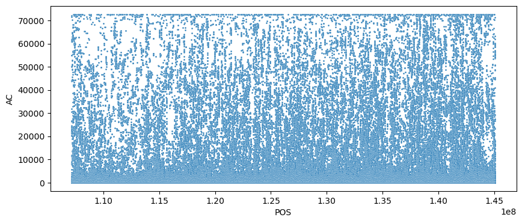

```python
plt.figure(figsize=(10, 4))
sns.scatterplot(data=df, x='POS', y='AC', s=4);
```

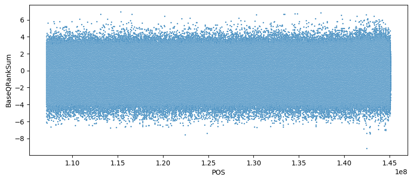

```python
plt.figure(figsize=(10, 4))
sns.scatterplot(data=df, x='POS', y='BaseQRankSum', s=4);
```

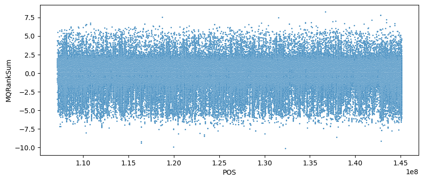

```python
plt.figure(figsize=(10, 4))
sns.scatterplot(data=df, x='POS', y='MQRankSum', s=4);
```

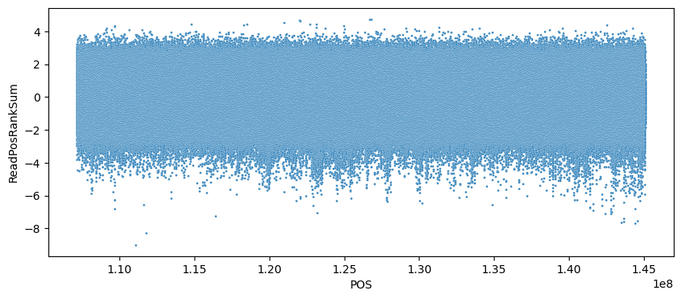

```python
plt.figure(figsize=(10, 4))
sns.scatterplot(data=df, x='POS', y='ReadPosRankSum', s=4);
```

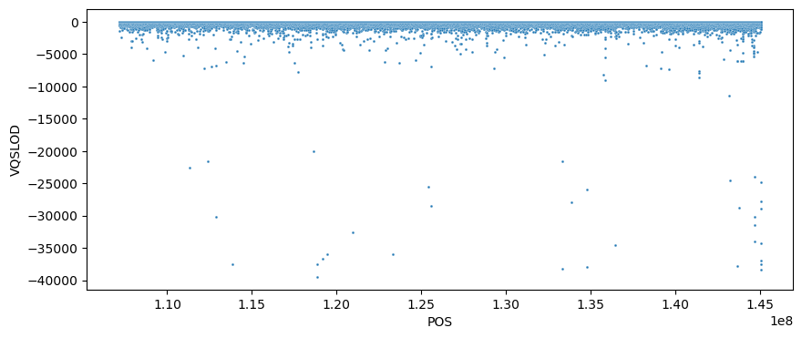

```python
plt.figure(figsize=(10, 4))
sns.scatterplot(data=df, x='POS', y='VQSLOD', s=4);
```

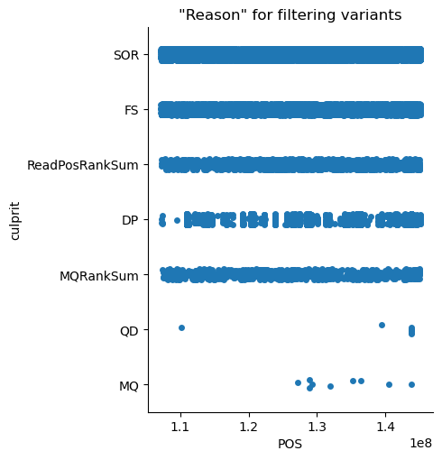

```python
sns.catplot(data=df.loc[df['Filtered'] ==1], x='POS', y='culprit').set(title='"Reason" for filtering variants');
```